# **Name** : **Bhavin Bhatt**

# **Title:** Analysing College Student Psychology

## **Sub-title:** Linear regression analysis of behaviour patterns

[figure not shown]

# **1) Objective of the Project**

### The primary aim of this research study is to leverage linear regression analysis as a tool for predicting and comprehending specific behavioral patterns among college students. Its goal is to provide valuable insights to the Psychology department of the San Francisco County Office of Education. To achieve this objective, a comprehensive survey was administered to graduate students at the University of the Pacific in San Francisco. The survey encompassed a wide array of questions related to various psychological traits, including empathy, confidence, goal orientation, social interactions, futuristic thinking, and more. The overarching purpose of this survey was to gain a deeper understanding of the thought processes and behavioral tendencies exhibited by graduate students.

### The study aims to uncover meaningful patterns and relationships within the collected data, shedding light on how different psychological traits interplay and influence student behavior. The insights derived from this research endeavor will serve as a foundational resource for conducting further research and enhancing the counseling services offered by the San Francisco County Office of Education.

# **2)Data Exploration**

We will explore different parts of data by doing Exploratory data analysis

```r
# importing the necessary libraries for our analysis
install.packages("readxl")
library(readxl)
library(tidyverse)
```

2.1) Importing all three excel files and Merging all three data frames. Displaying first 10 columns of final dataframe

```r
# Read the Excel file
df1 <- read_xlsx("/content/Class_2023_09_09__17_31_QZ_Personality Test-1.xlsx")
df2 <- read_xlsx("/content/Class_2023_09_09__17_47_QZ_Personality Test-1.xlsx")
df3 <- read_xlsx("/content/Class_2023_09_09__18_03_QZ_Personality Test-1.xlsx")

#Merging dataframes vertically
df_final <- rbind(df1, df2, df3)
head(df_final, 10)
dim(df_final)
```

A tibble: 10 × 51

| Socialite <dbl> | Dreamer <dbl> | Flexible Travel <dbl> | Overthinker <dbl> | Emotional Support <dbl> | Resilient <dbl> | Introvert <dbl> | Goal_oriented <dbl> | Nonchalant <dbl> | Social <dbl> | ⋯ | Friendly conversationalist <dbl> | Spontaneous task doer <dbl> | Mood swings <dbl> | Philosophical thinker <dbl> | Emotionally expressive <dbl> | Regret_free <dbl> | Pragmatic <dbl> | Compassionate <dbl> | Emotionally driven <dbl> | Self_assured <dbl> |
| --- | --- | --- | --- | --- | --- | --- | --- | --- | --- | --- | --- | --- | --- | --- | --- | --- | --- | --- | --- | --- |
| 5.0 | 9.0 | 10 | 6.5 | 8.5 | 5.0 | 0.0 | 10.0 | 8.0 | 5.5 | ⋯ | 7.0 | 8.0 | 10.0 | 6.0 | 8.5 | 10.0 | 8.0 | 10.0 | 10.0 | 8.5 |
| 4.0 | 5.5 | 5 | 8.0 | 1.0 | 8.0 | 6.0 | 8.0 | 8.0 | NA | ⋯ | NA | NA | NA | NA | NA | NA | NA | NA | NA | NA |
| 5.0 | 1.0 | 7 | 5.0 | 7.5 | 10.0 | 9.0 | 2.0 | 10.0 | 9.0 | ⋯ | NA | NA | NA | NA | NA | NA | NA | NA | NA | NA |
| 8.0 | 5.0 | 6 | 6.0 | 10.0 | 4.0 | 4.0 | 7.0 | 8.0 | 5.0 | ⋯ | 7.6 | 4.2 | 6.4 | 9.2 | 7.9 | 7.5 | 5.5 | 8.9 | 6.7 | 6.5 |
| 8.0 | 9.0 | 8 | 8.0 | 8.0 | 8.0 | 8.0 | 8.0 | 8.0 | 8.0 | ⋯ | NA | NA | NA | NA | NA | NA | NA | NA | NA | NA |
| 9.0 | 7.0 | 6 | 7.0 | 8.0 | 8.5 | 3.0 | 7.5 | 4.5 | 8.5 | ⋯ | 8.5 | 7.5 | 8.5 | 6.5 | 7.5 | 6.5 | 7.5 | 7.5 | 3.5 | 7.5 |
| 6.0 | 7.0 | 6 | 6.0 | 8.0 | 5.0 | 6.0 | 8.0 | 8.0 | 7.0 | ⋯ | NA | NA | NA | NA | NA | NA | NA | NA | NA | NA |
| 8.7 | 9.6 | 10 | 3.7 | 10.0 | 7.6 | 3.5 | 2.5 | 1.3 | 2.3 | ⋯ | NA | NA | NA | NA | NA | NA | NA | NA | NA | NA |
| 6.0 | 3.0 | 6 | 5.0 | 3.0 | 3.5 | 5.0 | 6.0 | 3.5 | 1.0 | ⋯ | NA | NA | NA | NA | NA | NA | NA | NA | NA | NA |
| 6.0 | NA | NA | NA | NA | NA | NA | NA | NA | NA | ⋯ | NA | NA | NA | NA | NA | NA | NA | NA | NA | NA |

1. 114

2. 51

2.2) Getting a list of the column names in the Dataframe

```r
# Replace spaces with underscores in column names
colnames(df_final) <- gsub(" ", "_", colnames(df_final))

# Updated column names
print(colnames(df_final))
```

```
 [1] "Socialite"                    "Dreamer"
 [3] "Flexible_Travel"              "Overthinker"
 [5] "Emotional_Support"            "Resilient"
 [7] "Introvert"                    "Goal_oriented"
 [9] "Nonchalant"                   "Social"
[11] "Detail_Oriented"              "Affectionate"
[13] "Systematic"                   "Long_term_Guilt"
[15] "Introverted_at_parties"       "Emotionally_uninvolved"
[17] "Indecisive_movie_picker"      "Calm_under_pressure"
[19] "Socially_confident"           "Vivid_dreamer"
[21] "Ruthless"                     "Determined"
[23] "Self_doubting"                "Reserved"
[25] "Practical"                    "Emotionally_reserved"
[27] "Love_bustling_places"         "Futuristic_thinker"
[29] "Emotionally_driven_decisions" "Require_tangible_field"
[31] "Vengeful"                     "Impulsive_Decision_Maker"
[33] "Solitude_lover"               "Deep_analyzer_movie_or_song"
[35] "Decisive"                     "Content_with_choices"
[37] "Solitude_loving"              "Present_oriented"
[39] "Empathyless"                  "Pre_planner"
[41] "Insecure_about_self_image"    "Friendly_conversationalist"
[43] "Spontaneous_task_doer"        "Mood_swings"
[45] "Philosophical_thinker"        "Emotionally_expressive"
[47] "Regret_free"                  "Pragmatic"
[49] "Compassionate"                "Emotionally_driven"
[51] "Self_assured"
```

2.3) Getting the total numberof rows & columns in our dataframe

```r
cat("Number of rows: ", nrow(df_final), "\n")
cat("Number of columns: ", ncol(df_final), "\n")
```

```
Number of rows:  114
Number of columns:  51
```

2.4) Getting summary of the dataframe

```r
summary(df_final)
```

```
   Socialite         Dreamer       Flexible_Travel   Overthinker
 Min.   :-2.000   Min.   : 0.000   Min.   : 0.000   Min.   : 0.00
 1st Qu.: 5.575   1st Qu.: 5.000   1st Qu.: 4.950   1st Qu.: 5.00
 Median : 7.000   Median : 7.000   Median : 7.000   Median : 7.00
 Mean   : 6.825   Mean   : 6.265   Mean   : 6.253   Mean   : 6.68
 3rd Qu.: 8.775   3rd Qu.: 8.000   3rd Qu.: 8.125   3rd Qu.: 8.55
 Max.   :10.000   Max.   :10.000   Max.   :10.000   Max.   :10.00
 NA's   :12       NA's   :14       NA's   :14       NA's   :14
 Emotional_Support   Resilient        Introvert      Goal_oriented
 Min.   : 1.000    Min.   : 1.000   Min.   : 0.000   Min.   : 1.000
 1st Qu.: 5.000    1st Qu.: 4.750   1st Qu.: 3.500   1st Qu.: 6.000
 Median : 7.000    Median : 6.500   Median : 6.000   Median : 8.000
 Mean   : 6.589    Mean   : 6.465   Mean   : 5.723   Mean   : 7.393
 3rd Qu.: 8.275    3rd Qu.: 8.000   3rd Qu.: 8.000   3rd Qu.: 8.850
 Max.   :10.000    Max.   :10.000   Max.   :11.000   Max.   :10.000
 NA's   :14        NA's   :15       NA's   :17       NA's   :19
   Nonchalant         Social       Detail_Oriented   Affectionate
 Min.   : 0.000   Min.   : 0.000   Min.   : 0.500   Min.   : 2.000
 1st Qu.: 4.125   1st Qu.: 2.000   1st Qu.: 4.000   1st Qu.: 8.000
 Median : 6.500   Median : 4.200   Median : 6.500   Median : 9.450
 Mean   : 6.122   Mean   : 4.917   Mean   : 6.113   Mean   : 8.712
 3rd Qu.: 8.000   3rd Qu.: 8.000   3rd Qu.: 8.000   3rd Qu.:10.000
 Max.   :10.000   Max.   :10.000   Max.   :10.000   Max.   :11.000
 NA's   :20       NA's   :21       NA's   :22       NA's   :22
   Systematic     Long_term_Guilt  Introverted_at_parties
 Min.   : 2.000   Min.   : 0.000   Min.   : 0.000
 1st Qu.: 5.725   1st Qu.: 4.000   1st Qu.: 4.000
 Median : 7.150   Median : 6.900   Median : 5.150
 Mean   : 7.036   Mean   : 6.075   Mean   : 5.552
 3rd Qu.: 8.550   3rd Qu.: 9.000   3rd Qu.: 7.600
 Max.   :12.000   Max.   :10.000   Max.   :10.000
 NA's   :22       NA's   :26       NA's   :28
 Emotionally_uninvolved Indecisive_movie_picker Calm_under_pressure
 Min.   : 1.000         Min.   : 1.000          Min.   : 1.000
 1st Qu.: 4.500         1st Qu.: 3.000          1st Qu.: 5.375
 Median : 6.000         Median : 6.000          Median : 7.700
 Mean   : 5.514         Mean   : 5.624          Mean   : 7.202
 3rd Qu.: 7.000         3rd Qu.: 8.000          3rd Qu.: 9.000
 Max.   :10.000         Max.   :11.000          Max.   :10.000
 NA's   :29             NA's   :30              NA's   :30
```

[output cut: 65 more lines]

```
 Min.   : 1.000         Min.   : 1.700   Min.   : 2.00   Min.   : 1.000
 1st Qu.: 2.725         1st Qu.: 4.000   1st Qu.: 4.25   1st Qu.: 5.000
 Median : 6.000         Median : 5.000   Median : 6.90   Median : 7.500
 Mean   : 5.409         Mean   : 6.028   Mean   : 6.27   Mean   : 6.754
 3rd Qu.: 7.600         3rd Qu.: 8.250   3rd Qu.: 8.00   3rd Qu.: 8.000
 Max.   :10.000         Max.   :10.000   Max.   :10.00   Max.   :10.000
 NA's   :70             NA's   :71       NA's   :71      NA's   :73
 Emotionally_driven  Self_assured
 Min.   : 1.000     Min.   :1.000
 1st Qu.: 2.850     1st Qu.:4.000
 Median : 4.500     Median :6.000
 Mean   : 4.979     Mean   :5.603
 3rd Qu.: 6.800     3rd Qu.:7.500
 Max.   :10.000     Max.   :9.000
 NA's   :74         NA's   :74
```

2.5) Replacing NA values in columns with their means

Note : Used chatgpt to understand and apply this code snippet

```r
#Replacing NA values in columns with their mean values
df_final[] <- lapply(df_final, function(x) ifelse(is.na(x), mean(x, na.rm = TRUE), x))
head(df_final,4)
```

A tibble: 4 × 51

| Socialite <dbl> | Dreamer <dbl> | Flexible_Travel <dbl> | Overthinker <dbl> | Emotional_Support <dbl> | Resilient <dbl> | Introvert <dbl> | Goal_oriented <dbl> | Nonchalant <dbl> | Social <dbl> | ⋯ | Friendly_conversationalist <dbl> | Spontaneous_task_doer <dbl> | Mood_swings <dbl> | Philosophical_thinker <dbl> | Emotionally_expressive <dbl> | Regret_free <dbl> | Pragmatic <dbl> | Compassionate <dbl> | Emotionally_driven <dbl> | Self_assured <dbl> |
| --- | --- | --- | --- | --- | --- | --- | --- | --- | --- | --- | --- | --- | --- | --- | --- | --- | --- | --- | --- | --- |
| 5 | 9.0 | 10 | 6.5 | 8.5 | 5 | 0 | 10 | 8 | 5.500000 | ⋯ | 7.000000 | 8.00000 | 10.000000 | 6.000000 | 8.500000 | 10.000000 | 8.000000 | 10.00000 | 10.000 | 8.5000 |
| 4 | 5.5 | 5 | 8.0 | 1.0 | 8 | 6 | 8 | 8 | 4.917204 | ⋯ | 6.185106 | 6.66087 | 5.713043 | 6.431111 | 5.409091 | 6.027907 | 6.269767 | 6.75439 | 4.979 | 5.6025 |
| 5 | 1.0 | 7 | 5.0 | 7.5 | 10 | 9 | 2 | 10 | 9.000000 | ⋯ | 6.185106 | 6.66087 | 5.713043 | 6.431111 | 5.409091 | 6.027907 | 6.269767 | 6.75439 | 4.979 | 5.6025 |
| 8 | 5.0 | 6 | 6.0 | 10.0 | 4 | 4 | 7 | 8 | 5.000000 | ⋯ | 7.600000 | 4.20000 | 6.400000 | 9.200000 | 7.900000 | 7.500000 | 5.500000 | 8.90000 | 6.700 | 6.5000 |

# **4) Simple Linear Regression**

### We will perform a simple linear regression with our **dependent variable** as below:

### **Goal-oriented column** - If you have to temporarily put your plans on hold, you make sure it is your top priority to get back on track as soon as possible.

### The purpose is to predict the behaviour amongst individuals who are more goal-oriented and how do different factors(independent variables) aid or hinder an individual's motivation to achieve goal. The following **independent variables** are chosen to predict the goal-oriented behaviour of a student.

### **1.Self_Assured** - You rarely feel insecure.

### **2.Calm_under_pressure** - You can stay calm under a lot of pressure.

### **3. Determined** - You are dedicated and focused on your goals, only rarely getting sidetracked.

### **4.Pre_planner** - When starting to work on a project, you prefer to make as many decisions upfront as possible.

### **5.Philosophical_thinker** - You often contemplate the reasons for human existence or the meaning of life

### **6.Self_doubting** - If you make a mistake, you tend to start doubting yourself, your abilities, or your knowledge

### **Model 1 - Self_Assured versus Goal-oriented**

```
Call:
lm(formula = Goal_oriented ~ Self_assured, data = df_final)

Residuals:
    Min      1Q  Median      3Q     Max
-6.0081 -0.8371  0.0000  1.0574  3.5682

Coefficients:
             Estimate Std. Error t value Pr(>|t|)
(Intercept)    5.0057     0.7377   6.786 5.76e-10 ***
Self_assured   0.4260     0.1281   3.325   0.0012 **
---
Signif. codes:  0 ‘***’ 0.001 ‘**’ 0.01 ‘*’ 0.05 ‘.’ 0.1 ‘ ’ 1

Residual standard error: 1.811 on 112 degrees of freedom
Multiple R-squared:  0.08982,	Adjusted R-squared:  0.0817
F-statistic: 11.05 on 1 and 112 DF,  p-value: 0.001197
```

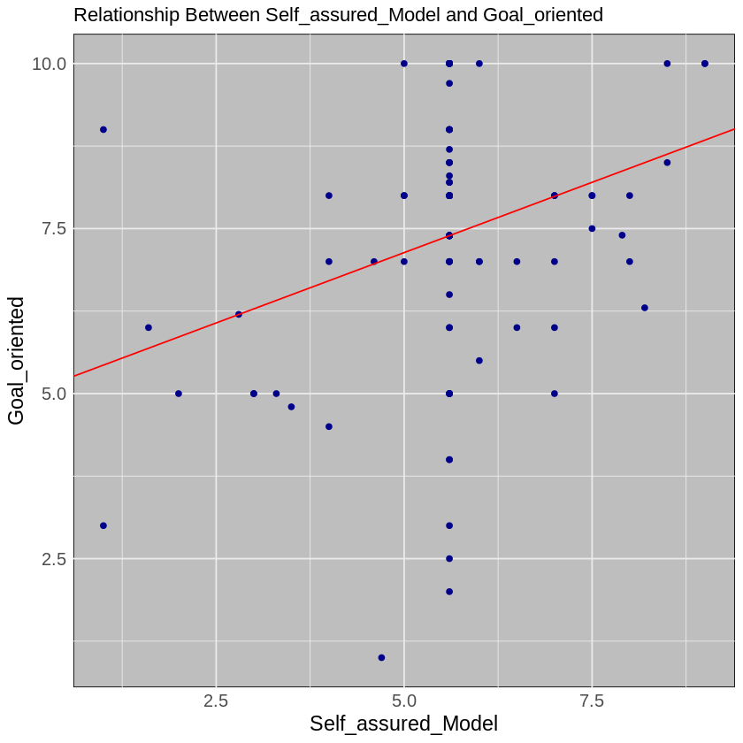

```r
Self_assured_Model <- lm(Goal_oriented ~ Self_assured, df_final)
summary(Self_assured_Model)

library(ggplot2)
#Socially_confident
plot1 <- ggplot(data = Self_assured_Model, aes(x = Self_assured , y = Goal_oriented)) +
  geom_point(color = "darkblue", shape = 19) +
  geom_abline(intercept = Self_assured_Model$coefficients[1], slope = Self_assured_Model$coefficients[2], color = "red", linetype = "solid") +
  labs(x = "Self_assured_Model", y = "Goal_oriented") +
  ggtitle("Relationship Between Self_assured_Model and Goal_oriented") +
  theme_minimal() +
  theme(axis.text = element_text(size = 12), axis.title = element_text(size = 14),

        panel.background = element_rect(fill = "grey"))


print(plot1)
```

### **Model 2 - Calm_under_pressure versus Goal-oriented** **bold text**

```
Call:
lm(formula = Goal_oriented ~ Calm_under_pressure, data = df_final)

Residuals:
   Min     1Q Median     3Q    Max
-6.302 -1.052  0.000  1.101  4.271

Coefficients:
                    Estimate Std. Error t value Pr(>|t|)
(Intercept)          4.54157    0.66184   6.862 3.95e-10 ***
Calm_under_pressure  0.39585    0.08903   4.446 2.07e-05 ***
---
Signif. codes:  0 ‘***’ 0.001 ‘**’ 0.01 ‘*’ 0.05 ‘.’ 0.1 ‘ ’ 1

Residual standard error: 1.75 on 112 degrees of freedom
Multiple R-squared:   0.15,	Adjusted R-squared:  0.1424
F-statistic: 19.77 on 1 and 112 DF,  p-value: 2.067e-05
```

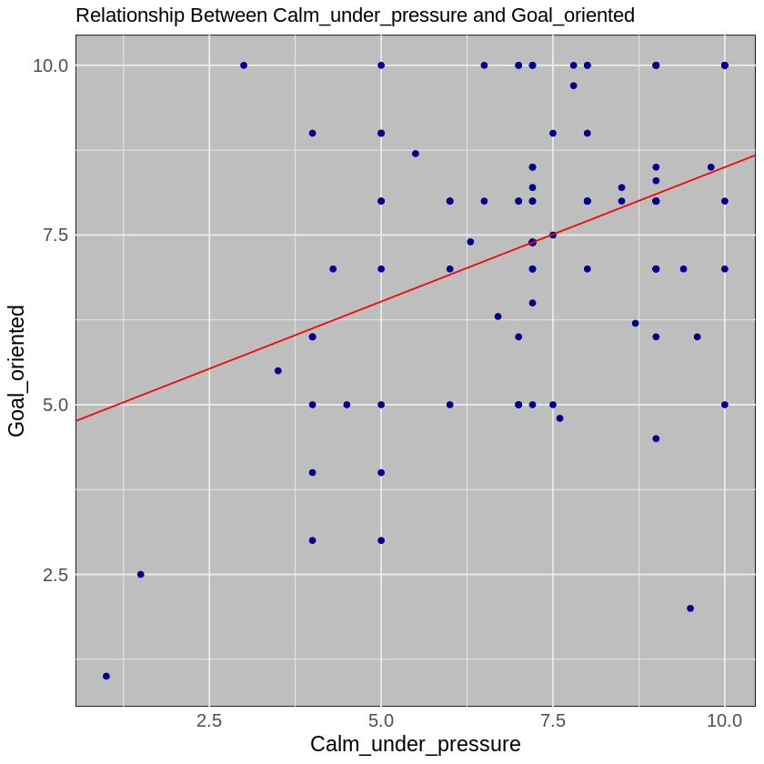

```r
Calm_Model <- lm(Goal_oriented ~ Calm_under_pressure, df_final)
summary(Calm_Model)

library(ggplot2)
#Socially_confident
plot2 <- ggplot(data = Calm_Model, aes(x = Calm_under_pressure , y = Goal_oriented)) +
  geom_point(color = "darkblue", shape = 19) +
  geom_abline(intercept = Calm_Model$coefficients[1], slope = Calm_Model$coefficients[2], color = "red", linetype = "solid") +
  labs(x = "Calm_under_pressure", y = "Goal_oriented") +
  ggtitle("Relationship Between Calm_under_pressure and Goal_oriented") +
  theme_minimal() +
  theme(axis.text = element_text(size = 12), axis.title = element_text(size = 14),

        panel.background = element_rect(fill = "grey"))


print(plot2)
```

### **Summary**: The graph above shows a positive co-relation between Goal_oriented and Calm_under_pressure. As can be seen from the summary the p value < 0.05 and R-square value of 0.15 indicates that a model is statiscally significant as can be seen from the slope of the graph above. Thus it can be concluded that being calm_under_pressure seems to be associated with a high goal oriented behaviour.

### **Model 3 - Determined versus Goal-oriented**

```
Call:
lm(formula = Goal_oriented ~ Determined, data = df_final)

Residuals:
    Min      1Q  Median      3Q     Max
-5.9086 -0.8557  0.0000  1.0468  3.5098

Coefficients:
            Estimate Std. Error t value Pr(>|t|)
(Intercept)  4.12617    0.61021   6.762 6.46e-10 ***
Determined   0.47281    0.08533   5.541 2.02e-07 ***
---
Signif. codes:  0 ‘***’ 0.001 ‘**’ 0.01 ‘*’ 0.05 ‘.’ 0.1 ‘ ’ 1

Residual standard error: 1.682 on 112 degrees of freedom
Multiple R-squared:  0.2151,	Adjusted R-squared:  0.2081
F-statistic:  30.7 on 1 and 112 DF,  p-value: 2.021e-07
```

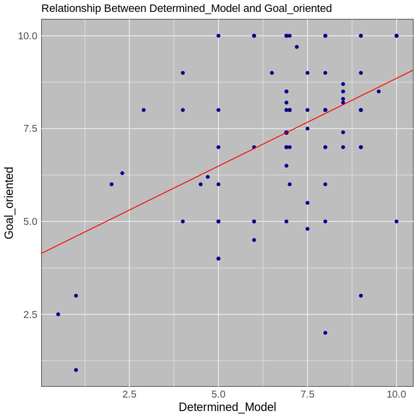

```r
Determined_Model <- lm(Goal_oriented ~ Determined, df_final)
summary(Determined_Model)

library(ggplot2)
#Socially_confident
plot3 <- ggplot(data = Determined_Model, aes(x = Determined , y = Goal_oriented)) +
  geom_point(color = "darkblue", shape = 19) +
  geom_abline(intercept = Determined_Model$coefficients[1], slope = Determined_Model$coefficients[2], color = "red", linetype = "solid") +
  labs(x = "Determined_Model", y = "Goal_oriented") +
  ggtitle("Relationship Between Determined_Model and Goal_oriented") +
  theme_minimal() +
  theme(axis.text = element_text(size = 12), axis.title = element_text(size = 14),

        panel.background = element_rect(fill = "grey"))


print(plot3)
```

### **Summary**: The graph for our model above shows a positive relation between our Goal_oriented variable and independent variable Determined.The p value suggests that there is significant relationship between the Determined variable and Goal_oriented *variable*. The R squared value of 0.2081 shows that a 20.81% variation in goal-oriented is affected by Determined column. This means that determined person is more likely to be Goal-Oriented person and these qualities make them more likely to achieve their goals

### **Model 4 - Pre_planner versus Goal-oriented**

```
Call:
lm(formula = Goal_oriented ~ Pre_planner, data = df_final)

Residuals:
    Min      1Q  Median      3Q     Max
-6.8766 -0.7019  0.0000  0.9802  3.0044

Coefficients:
            Estimate Std. Error t value Pr(>|t|)
(Intercept)   6.3880     0.8917   7.164 8.82e-11 ***
Pre_planner   0.1519     0.1321   1.149    0.253
---
Signif. codes:  0 ‘***’ 0.001 ‘**’ 0.01 ‘*’ 0.05 ‘.’ 0.1 ‘ ’ 1

Residual standard error: 1.887 on 112 degrees of freedom
Multiple R-squared:  0.01166,	Adjusted R-squared:  0.002835
F-statistic: 1.321 on 1 and 112 DF,  p-value: 0.2528
```

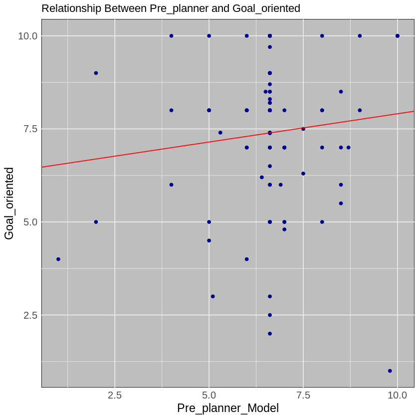

```r
Pre_planner_Model <- lm(Goal_oriented ~ Pre_planner, df_final)
summary(Pre_planner_Model)

library(ggplot2)
#Socially_confident
plot4 <- ggplot(data = Pre_planner_Model, aes(x = Pre_planner , y = Goal_oriented)) +
  geom_point(color = "darkblue", shape = 19) +
  geom_abline(intercept = Pre_planner_Model$coefficients[1], slope = Pre_planner_Model$coefficients[2], color = "red", linetype = "solid") +
  labs(x = "Pre_planner_Model", y = "Goal_oriented") +
  ggtitle("Relationship Between Pre_planner and Goal_oriented") +
  theme_minimal() +
  theme(axis.text = element_text(size = 12), axis.title = element_text(size = 14),

        panel.background = element_rect(fill = "grey"))


print(plot4)
```

### **Summary**: The graph for our model above shows a positive relation between our Goal_oriented variable and independent variable Pre_planner.The model is not statistically significant as the p value is greater than 0.05. The R square value of 0.0.002835 shows only less amount a variance between the variables. Although there is some relation between the two it also shows that a Pre_Planner quality of an idividual does not neccesarily guarantee that the person might be goal_oriented and there might be other factors that affect the goal_oriented quality.

### **Model 5 - Philosophical_thinker versus Goal-oriented**

```r
Philosophical_thinker_Model <- lm(Goal_oriented ~ Philosophical_thinker, df_final)
summary(Philosophical_thinker_Model)

library(ggplot2)
#Socially_confident
plot5 <- ggplot(data = Philosophical_thinker_Model, aes(x = Philosophical_thinker , y = Goal_oriented)) +
  geom_point(color = "darkblue", shape = 19) +
  geom_abline(intercept = Philosophical_thinker_Model$coefficients[1], slope = Philosophical_thinker_Model$coefficients[2], color = "red", linetype = "solid") +
  labs(x = "Philosophical_thinker_Model", y = "Goal_oriented") +
  ggtitle("Relationship Between Philosophical_thinker and Goal_oriented") +
  theme_minimal() +
  theme(axis.text = element_text(size = 12), axis.title = element_text(size = 14),

        panel.background = element_rect(fill = "grey"))


print(plot5)
```

[output not shown]

```
Call:
lm(formula = Goal_oriented ~ Philosophical_thinker, data = df_final)

Residuals:
    Min      1Q  Median      3Q     Max
-5.4381 -0.8633  0.0000  1.1074  3.5619

Coefficients:
                      Estimate Std. Error t value Pr(>|t|)
(Intercept)             9.1127     0.8264  11.027   <2e-16 ***
Philosophical_thinker  -0.2675     0.1256  -2.129   0.0354 *
---
Signif. codes:  0 ‘***’ 0.001 ‘**’ 0.01 ‘*’ 0.05 ‘.’ 0.1 ‘ ’ 1

Residual standard error: 1.861 on 112 degrees of freedom
Multiple R-squared:  0.03891,	Adjusted R-squared:  0.03033
F-statistic: 4.534 on 1 and 112 DF,  p-value: 0.03541
```

### **Model 6 - Self_doubting versus Goal-oriented**

```
Call:
lm(formula = Goal_oriented ~ Self_doubting, data = df_final)

Residuals:
    Min      1Q  Median      3Q     Max
-6.4732 -0.6230  0.0000  0.9636  2.9548

Coefficients:
              Estimate Std. Error t value Pr(>|t|)
(Intercept)    7.90123    0.54987  14.369   <2e-16 ***
Self_doubting -0.08560    0.08762  -0.977    0.331
---
Signif. codes:  0 ‘***’ 0.001 ‘**’ 0.01 ‘*’ 0.05 ‘.’ 0.1 ‘ ’ 1

Residual standard error: 1.89 on 112 degrees of freedom
Multiple R-squared:  0.00845,	Adjusted R-squared:  -0.0004036
F-statistic: 0.9544 on 1 and 112 DF,  p-value: 0.3307
```

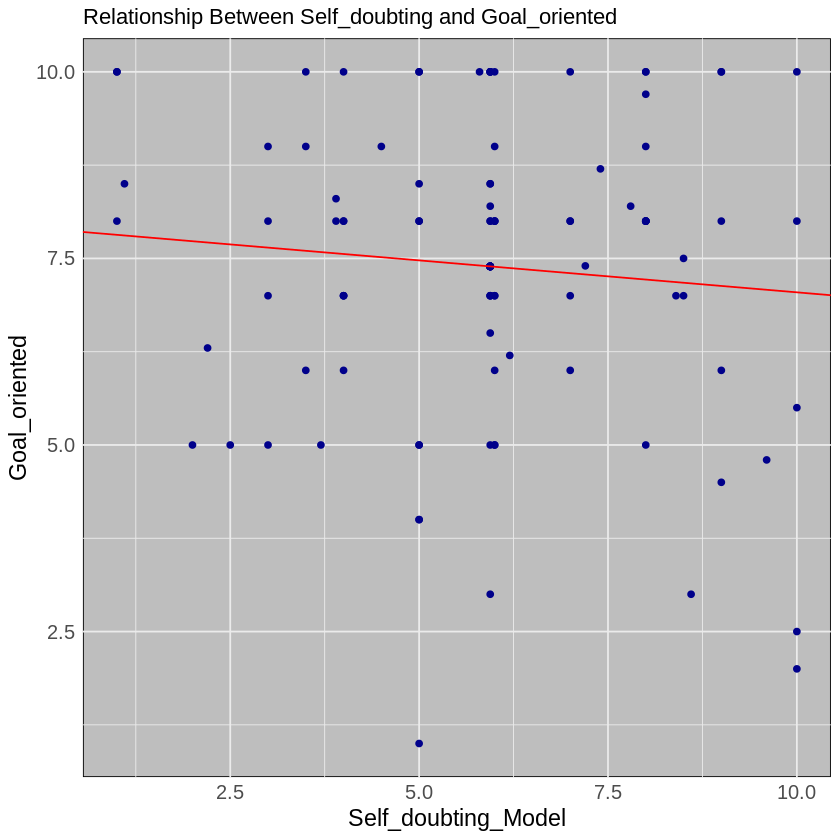

```r
Self_doubting_Model <- lm(Goal_oriented ~ Self_doubting, df_final)
summary(Self_doubting_Model)

library(ggplot2)
#Socially_confident
plot6 <- ggplot(data = Self_doubting_Model, aes(x = Self_doubting , y = Goal_oriented)) +
  geom_point(color = "darkblue", shape = 19) +
  geom_abline(intercept = Self_doubting_Model$coefficients[1], slope = Self_doubting_Model$coefficients[2], color = "red", linetype = "solid") +
  labs(x = "Self_doubting_Model", y = "Goal_oriented") +
  ggtitle("Relationship Between Self_doubting and Goal_oriented") +
  theme_minimal() +
  theme(axis.text = element_text(size = 12), axis.title = element_text(size = 14),

        panel.background = element_rect(fill = "grey"))


print(plot6)
```

### **Summary**: The Self_doubting_model above shows a negative relation between Goal_oriented and Self_doubting variable. The p value of 0.3307 which is above 0.05 suggests that the model might not have significant impact on the Goal_oriented variable. The R-squared value: 0.00845 suggests Goal_oriented variable might not have much variance from Self_doubting variable but it does impact it. Thus a person with Self_doubting quality although not significant but might have some negative impact in their Goal_oriented quality and there might be some other factors which will affect the goal oriented quality.

# **5) Model comparison**

```r
install.packages("ggplot2")
install.packages("ggpubr")
```

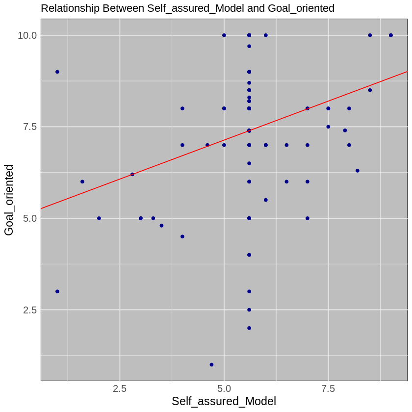

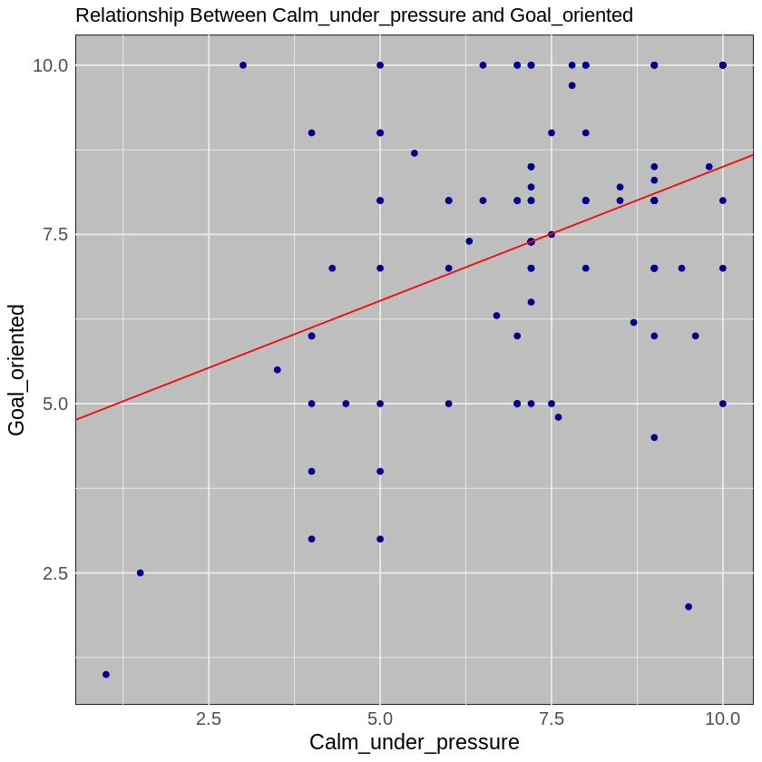

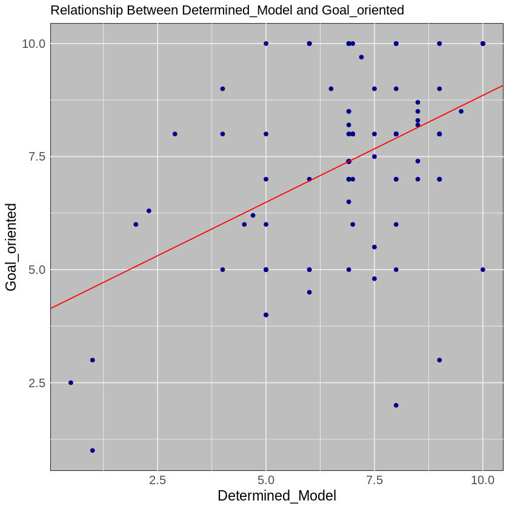

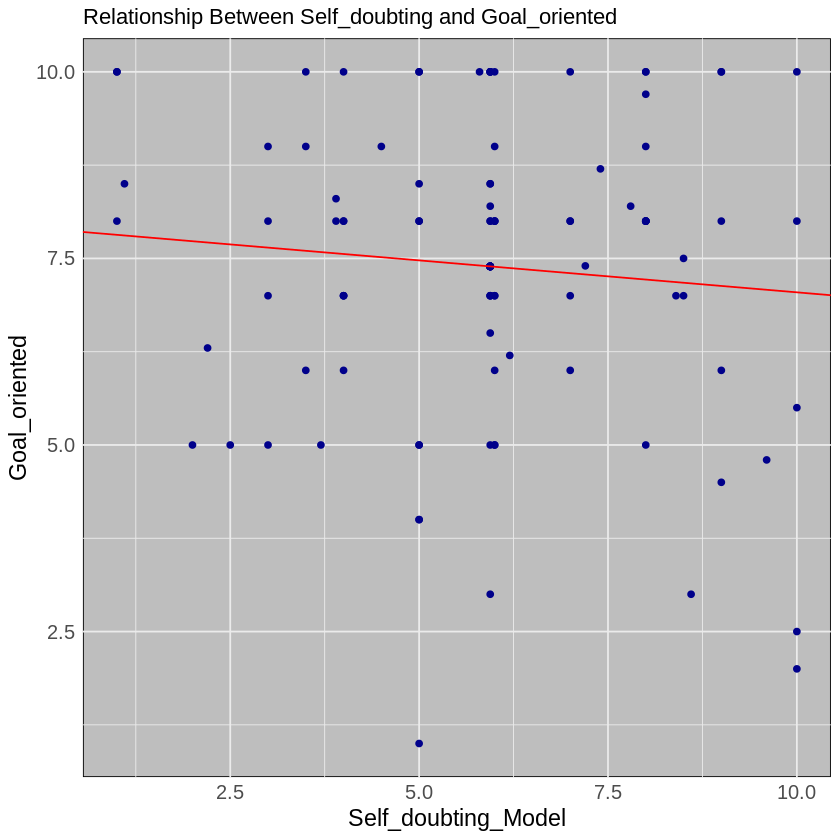

```r
print(plot1)
print(plot2)
print(plot3)
print(plot4)
print(plot5)
print(plot6)
```

[output not shown]

### Summary: Among the models described, the most promising model for predicting Goal-oriented behavior appears to be the one relating Goal_oriented to the independent variable "Determined." This model has a relatively high R-squared value of 0.2081, indicating that approximately 20.81% of the variation in Goal-oriented behavior can be explained by the Determined variable. Additionally, the p-value suggests a significant relationship between Determined and Goal_oriented, making it statistically significant. This means that individuals who exhibit determination are more likely to be Goal-oriented, and these qualities contribute to their likelihood of achieving their goals. The strong R-squared value and significant p-value make this model a reliable choice for predicting Goal-oriented behavior.

### On the other hand, the model involving "Self_doubting" as an independent variable has a less favorable performance. The p-value of 0.3307 is above the commonly used significance level of 0.05, indicating that the model might not have a significant impact on Goal-oriented behavior. The R-squared value of 0.00845 suggests that there is not much variance in Goal-oriented behavior explained by Self-doubting, and any impact it has is relatively minor. While there is some negative impact indicated, it is not statistically robust, and there might be other factors at play that affect Goal-oriented behavior. Therefore, the Self_doubting model is less reliable for predicting Goal-oriented behavior compared to the Determined model.

## **6) Multiple Linear Regression**

### From the results obtained from all the simple linear regression models above, we will now proceed with designing multiple linear regression models using combinations of variables used in the simple linear models.

```
Call:
lm(formula = Goal_oriented ~ Self_assured + Calm_under_pressure +
    Determined + Pre_planner, data = df_final)

Residuals:
    Min      1Q  Median      3Q     Max
-6.3180 -0.6685  0.0000  0.9169  4.3814

Coefficients:
                    Estimate Std. Error t value Pr(>|t|)
(Intercept)          2.14940    1.01928   2.109  0.03726 *
Self_assured         0.26580    0.12300   2.161  0.03289 *
Calm_under_pressure  0.25082    0.09026   2.779  0.00642 **
Determined           0.31985    0.09360   3.417  0.00089 ***
Pre_planner         -0.03963    0.11822  -0.335  0.73809
---
Signif. codes:  0 ‘***’ 0.001 ‘**’ 0.01 ‘*’ 0.05 ‘.’ 0.1 ‘ ’ 1

Residual standard error: 1.617 on 109 degrees of freedom
Multiple R-squared:  0.2936,	Adjusted R-squared:  0.2677
F-statistic: 11.33 on 4 and 109 DF,  p-value: 1.009e-07
```

[figure not shown]

```r
# Load the ggplot2 library

library(ggplot2)

# Creating a  multiple linear regression model
Positive_model <- lm(Goal_oriented  ~ Self_assured + Calm_under_pressure + Determined + Pre_planner , data = df_final)
summary(Positive_model)
# Create a scatter plot with regression line
# Create a scatter plot with regression lines
plot <- ggplot(data = df_final, aes(x = Self_assured + Calm_under_pressure + Determined + Pre_planner, y = Goal_oriented )) +
  geom_point(color = "darkblue", shape = 19) +
  geom_smooth(method = "lm", se = FALSE, color = "red") +
  labs(x = "Goal_oriented", y = "Self_assured + Calm_under_pressure + Determined + Pre_planner") +
  ggtitle("Multiple Linear Regression: Goal_oriented vs Self_assured + Calm_under_pressure + Determined + Pre_planner") +
  theme_minimal() +
  theme(axis.text = element_text(size = 12),
        axis.title = element_text(size = 14),
        plot.title = element_text(size = 16))

print(plot)
```

### **Comparison: Positive_Model vs Determined_Model**

### The models Determined_model and Positive_model show statistical significance with very low p-values, indicating that they are valuable in explaining the variance in Goal_oriented. However, when comparing these two models, Positive_model which is the multiple linear regression model, is likely the better choice. It incorporates additional independent variables (Self_assured, Calm_under_pressure, and Pre_planner), leading to a higher R-squared value of 0.2936 vs 0.2151. This suggests that Psotive_model accounts for more variability in the dependent variable, making it a more comprehensive model for predicting Goal_oriented behavior.

### 1) The Second multiple linear regression model known as **Negative_model** we created contains the 2 different categories of variables mainly:

### a). Philosophical_thinker

### b) Self_doubting

```
Call:
lm(formula = Goal_oriented ~ Philosophical_thinker + Self_doubting,
    data = df_final)

Residuals:
    Min      1Q  Median      3Q     Max
-5.5009 -0.7601  0.0000  1.0917  3.5760

Coefficients:
                      Estimate Std. Error t value Pr(>|t|)
(Intercept)            9.73337    0.99615   9.771   <2e-16 ***
Philosophical_thinker -0.27521    0.12567  -2.190   0.0306 *
Self_doubting         -0.09608    0.08631  -1.113   0.2680
---
Signif. codes:  0 ‘***’ 0.001 ‘**’ 0.01 ‘*’ 0.05 ‘.’ 0.1 ‘ ’ 1

Residual standard error: 1.859 on 111 degrees of freedom
Multiple R-squared:  0.04952,	Adjusted R-squared:  0.03239
F-statistic: 2.892 on 2 and 111 DF,  p-value: 0.05968
```

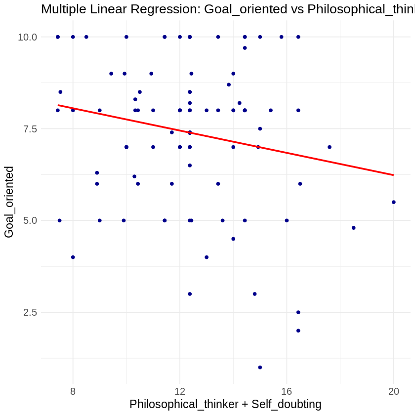

```r
# Load the ggplot2 library

library(ggplot2)

# Creating a  multiple linear regression model
Negative_model <- lm(Goal_oriented ~ Philosophical_thinker + Self_doubting  , data = df_final)
summary(Negative_model)
# Create a scatter plot with regression line
# Create a scatter plot with regression lines
plot <- ggplot(data = df_final, aes(x = Philosophical_thinker + Self_doubting , y = Goal_oriented)) +
  geom_point(color = "darkblue", shape = 19) +
  geom_smooth(method = "lm", se = FALSE, color = "red") +
  labs(x = "Philosophical_thinker + Self_doubting", y = "Goal_oriented") +
  ggtitle("Multiple Linear Regression: Goal_oriented vs Philosophical_thinker + Self_doubting") +
  theme_minimal() +
  theme(axis.text = element_text(size = 12),
        axis.title = element_text(size = 14),
        plot.title = element_text(size = 16))

print(plot)
```

### **Summary**: It can be seen from the Negative model above that the relationship between Philosopher_thinker + Self_doubting and Goal_oriented is negative.

### The low R-squared value (0.04952) suggests that this model explains only a small portion of the variability in Goal_oriented behavior. The p value of 0.05968 suggestes that there isn't much significant impact on Goal_oriented behaviour.

# **7) Summary**

### The analysis evaluates various models for predicting Goal-oriented behavior based on different independent variables. Here are the key findings:

### **Determined Mode**l: This model uses the "Determined" variable as an independent variable and has an R-squared value of 0.2081, indicating that approximately 20.81% of the variation in Goal-oriented behavior can be explained by determination. The p-value suggests a significant relationship between Determined and Goal-oriented, making it a reliable choice for prediction.

### **Self-doubting Model**: In contrast, the model using "Self_doubting" as an independent variable performs less favorably. It has a higher p-value (0.3307) and a lower R-squared value (0.00845), indicating that Self-doubting has a minor and statistically less significant impact on Goal-oriented behavior.

### **Positive Model**: This model combines multiple independent variables, including Self_assured, Calm_under_pressure, Determined, and Pre_planner, and has an R-squared value of 0.2936. These traits are positively associated with Goal-oriented behavior, explaining 29.36% of its variance.

### **Comparison between Models**: When comparing the Determined Model and Positive Model, the latter is preferred due to its higher R-squared value, indicating it accounts for more variability in Goal-oriented behavior. Both models are statistically significant.

### **Negative Model**: This model considers Philosopher_thinker and Self_doubting as independent variables and shows a negative relationship with Goal-oriented behavior. However, it has a low R-squared value (0.04952) and a p-value (0.05968) that suggests weak statistical significance.

# **8)Recommendation**

### The Positive Model, which includes Self_assured, Calm_under_pressure, Determined, and Pre_planner variables, is the most comprehensive and effective model for predicting Goal-oriented behavior. It explains a significant portion about 29.36% of the variance and provides valuable insights into the traits that contribute positively to goal achievement. Therefore, when trying to understand or predict Goal-oriented behavior, consider using this model.

### While negative traits such as Philosopher_thinker and Self_doubting have a negative impact although very less we must avoid considering this as an individual predictor of negative impact and look at things in a whole context.

### It is important to note that a larger dataset would have provided us a more comprehensive understanding of the behaviours among students. It is also important to know that individual behaviours are also influenced from other factors such as the social structure around individuals for example country of origin, individual experiences in life and past trauma or incidences that might affect the results. Thus in general although Positive_model gives a better understanding but we should also consider various other factors before arriving at any conclusion.